# Modeling-effort

Consultation notes with Daniela

Sarka Kadava

2024-10-17

# Introduction

The experimental design is described in the preregistration here: https://osf.io/m9xep (@Daniela, you can skip the section Lab Equipment)

In this markdown, we will be modelling the causal relation between effort and correction to confirm/reject our hypothesis.

These are:

H1: In corrections, people will enhance some effort-related kinematic and/or acoustic features of their behaviour

H2: The enhancement will depend on similarity of the guesser’s answer and the original meaning. More similar answer will require/result in smaller enhancement (but still enhancement) than less similar answer.

# Setting up the environment

```r
library(here)
library(dagitty) # for dag
library(dplyr) # for data-wrangling
library(lme4)  # for linear mixed-effects models
library(tidyr)  # for reshaping data (if needed)
```

# DAG

To make sure we know what variables should be in the model and why, we draw a DAG that illustrates our assumptions

Our relationship of interest is the causal effect of communicative attempt on effort.

Other assumptions include:

Personality traits (measured with Big5) will influence effort (e.g., people are more willing to put more effort if they are open-minded) and also communicative attempt (e.g., more extroverted people are better in this game, therefore they need less attempts)

Familiarity with guessing partner influences effort (ditto) as well as communicative attempt (e.g., friends are better in this game than strangers)

Similarly, participant will also directly infleunce effort and commAtt, because personality traits might not be capturing all variation

Expressibility of concepts is going to influence effort (e.g., more expressible concepts allow more enhancement - but could be also other direction) as well as CommAtt (e.g., more expressible concepts are more readily guessed and don’t need more attempts)

Similarly, concept will also directly influence effort and commAtt, because expressibility might not be capturing all variation

Modality (uni vs. multi) will influence the value of effort. We assume that in unimodal condition, the feature does not need to account for synergic relations with the other modality, and may carry the whole signal. In multimodal condition, however, there may be synergic relations that moderate the full expressiveness of this feature

Lastly, trial number (characterising how for one is in the experiment) could be hinting on learning processes through out the experiment, or - the other direction - on increasing fatigue

```
## Plot coordinates for graph not supplied! Generating coordinates, see ?coordinates for how to set your own.
```

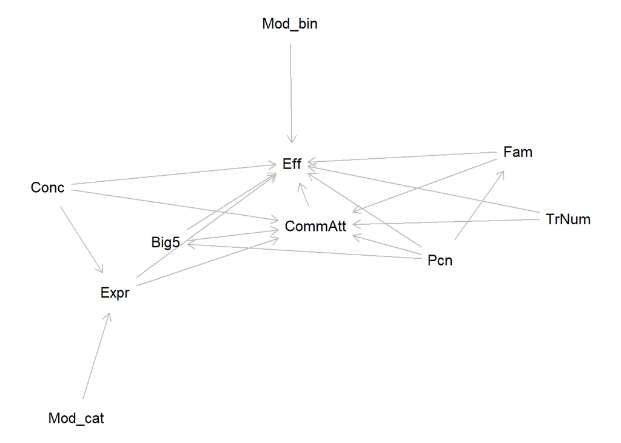

```r
dag <- dagitty('dag {
Big5 [adjusted,pos="-0.823,0.657"]
CommAtt [exposure,pos="-1.033,0.028"]
Conc [adjusted,pos="-1.136,-0.848"]
Eff [outcome,pos="-0.102,0.025"]
Expr [adjusted,pos="-0.758,-0.850"]
Fam [adjusted,pos="-0.379,0.663"]
Mod_cat [adjusted,pos="-0.374,-0.850"]
Pcn [adjusted,pos="-0.589,1.214"]
TrNum [adjusted,pos="-1.686,-0.859"]
Big5 -> CommAtt
Big5 -> Eff
CommAtt -> Eff
Conc -> Expr
Expr -> CommAtt
Expr -> Eff
Fam -> CommAtt
Fam -> Eff
Mod_bin -> Eff
Mod_cat -> Expr
Pcn -> Big5
Pcn -> CommAtt
Pcn -> Eff
Pcn -> Fam
TrNum -> CommAtt
TrNum -> Eff
Conc -> CommAtt
Conc -> Eff
}')

plot(dag)
```

# Synthetic data

We will now create synth data that will copy the relations we assume in our DAG. Assigning concrete coefficients will also help us to test our model - we should find exactly those causalities that we had in mind when creating these data

```r
# Set seed for reproducibility
set.seed(0209)

# Define participants, total unique concepts, and modalities
n_participants <- 120
n_total_concepts <- 21  # Total unique concepts
n_concepts_per_participant <- 21  # Each participant works with 21 concepts
n_modalities <- 3  # gesture, vocal, combined

# Generate participant IDs
participants <- 1:n_participants

# Simulate Big5 personality traits (standardized between 0 and 1) and Familiarity (between 0 and 1) for participants
Big5 <- runif(n_participants, min = 0, max = 1)  # Continuous values between 0 and 1
Familiarity <- runif(n_participants, min = 0, max = 1)  # Continuous values between 0 and 1

# Create a matrix to hold expressibility values for each concept in each modality
expressibility_matrix <- matrix(runif(n_total_concepts * n_modalities, min = 0, max = 1), nrow = n_total_concepts, ncol = n_modalities)

# Randomly sample 21 unique concepts for each participant
final_data <- data.frame()

# Define a function to assign CommAtt and Eff for a single participant
simulate_participant <- function(participant_id) {
  # Randomly sample 21 unique concepts from the total pool of 84
  selected_concepts <- sample(1:n_total_concepts, n_concepts_per_participant)

  participant_data <- data.frame()
  trial_number <- 1  # Initialize trial number

  for (concept_id in selected_concepts) {
    # Randomly determine the modality for the concept
    modality <- sample(c("gesture", "vocal", "combined"), 1)

    # Calculate expressibility based on modality
    expressibility_score <- ifelse(modality == "vocal", expressibility_matrix[concept_id, 1] * 0.6,
                                    ifelse(modality == "gesture", expressibility_matrix[concept_id, 2],
                                           expressibility_matrix[concept_id, 3] * 1.2))

    # Determine Communicative Attempts based solely on expressibility, familiarity, and Big5
    base_prob <- c(0.33, 0.33, 0.33)  # Equal chance for 1, 2, or 3 attempts

    # Modify probabilities based on familiarity, Big5, and expressibility
    adjusted_prob <- base_prob * c(1 - Familiarity[participant_id], # 3 times for each
                                    1 - Familiarity[participant_id],
                                    1 - Familiarity[participant_id]) *
                     c(1 - Big5[participant_id],
                       1 - Big5[participant_id],
                       1 - Big5[participant_id]) *
                     c(1 - expressibility_score,
                       1 - expressibility_score,
                       1 - expressibility_score)

    # Normalize the adjusted probabilities
    adjusted_prob <- adjusted_prob / sum(adjusted_prob)

    # Sample the number of communicative attempts based on adjusted probabilities
    n_attempts <- sample(1:3, 1, prob = adjusted_prob)

    # Loop through the number of attempts and increment CommAtt correctly
    for (attempt in 1:n_attempts) {
      # Calculate Eff for the first attempt
      if (attempt == 1) {
        Eff <- 1.15 * Big5[participant_id] +
               1.10 * Familiarity[participant_id] +
               1.20 * expressibility_score +
               rnorm(1, mean = 1, sd = 0.5)

        # Adjust Eff based on modality
        if (modality == "combined") {

          Eff <- Eff * 0.7  # Slight moderation for combined modality
        }
      }

      # Adjust Eff for subsequent attempts
      if (attempt == 2) {
        Eff <- 1.15 * Big5[participant_id] +
               1.10 * Familiarity[participant_id] +
               1.20 * expressibility_score +
               rnorm(1, mean = 1, sd = 0.5)
        Eff <- Eff * 1.50  # Multiply effort by 1.50 for the second attempt
      } else if (attempt == 3) {
        Eff <- 1.15 * Big5[participant_id] +
               1.10 * Familiarity[participant_id] +
               1.20 * expressibility_score +
               rnorm(1, mean = 1, sd = 0.5)
        Eff <- Eff * 0.70  # Multiply effort by 0.70 for the third attempt
      }

      # Create row for each attempt
      participant_data <- rbind(participant_data, data.frame(
        Participant = participant_id,
        Concept = concept_id,
        Modality = modality,
        Big5 = Big5[participant_id],
        Familiarity = Familiarity[participant_id],
        Expressibility = expressibility_score,
        CommAtt = attempt,  # Correctly set the attempt number
        Eff = Eff,
        TrialNumber = trial_number  # Set trial number for this attempt
      ))

      # Increment the trial number after each attempt
      trial_number <- trial_number + 1
    }
  }

  return(participant_data)
}

# Simulate data for all participants
for (i in participants) {
  final_data <- rbind(final_data, simulate_participant(i))
}

# Preview the first few rows of the final data
head(final_data)
```

```
##   Participant Concept Modality      Big5 Familiarity Expressibility CommAtt
## 1           1       3 combined 0.9599493   0.9219529     0.07567109       1
## 2           1       3 combined 0.9599493   0.9219529     0.07567109       2
## 3           1       3 combined 0.9599493   0.9219529     0.07567109       3
## 4           1       9    vocal 0.9599493   0.9219529     0.37757391       1
## 5           1       9    vocal 0.9599493   0.9219529     0.37757391       2
## 6           1      21  gesture 0.9599493   0.9219529     0.56918606       1
##        Eff TrialNumber
## 1 2.624256           1
## 2 2.715052           2
## 3 2.650435           3
## 4 3.498290           4
## 5 5.902036           5
## 6 3.246798           6
```

So now we have synthetic data where we exactly defined (using coefficients) what is the relationship between certain variables

1. CommAtt -> Eff

2. Fam -> Eff & CommAtt

3. Big5 -> Eff & CommAtt

4. Expr -> Eff & CommAtt

5. TrNum -> Eff & CommAtt

Beta = could be both neg (fatigue) or positive (learning)

## DP exploring

```r
nrow(final_data)
```

```
## [1] 5055
```

```r
final_data |>
  janitor::tabyl(Participant, Concept)
```

```
##  Participant 1 2 3 4 5 6 7 8 9 10 11 12 13 14 15 16 17 18 19 20 21
##            1 3 2 3 3 3 1 1 1 2  1  2  2  3  1  1  2  1  1  3  2  2
##            2 2 1 2 3 3 3 2 1 2  1  1  2  1  1  3  3  2  2  2  3  3
##            3 3 3 3 2 1 3 2 1 3  1  2  3  1  3  3  3  2  3  1  1  3
##            4 3 3 3 1 2 3 2 2 1  3  1  3  1  1  2  3  1  2  2  2  2
##            5 2 1 2 1 2 3 3 1 2  1  3  2  1  3  3  2  1  2  2  2  3
##            6 2 2 3 3 3 3 1 2 3  2  1  3  2  1  2  1  2  3  2  1  3
##            7 2 3 3 2 2 3 3 3 3  1  3  3  2  3  3  2  2  2  3  3  3
##            8 1 2 2 1 2 2 1 3 2  2  2  3  1  1  3  3  2  3  1  3  1
##            9 1 1 1 2 3 1 3 2 1  1  2  1  2  3  3  2  1  3  3  3  1
##           10 2 1 3 2 3 2 1 1 2  2  2  3  3  1  1  3  3  3  1  3  2
##           11 3 2 3 3 3 3 1 2 3  3  1  1  3  2  3  2  2  3  3  1  2
##           12 2 3 3 2 3 2 3 3 2  1  3  1  1  3  3  1  2  1  1  1  3
##           13 1 2 2 1 3 1 3 1 2  2  3  3  3  1  3  3  2  1  2  1  1
##           14 3 2 2 2 1 2 3 2 2  3  1  2  3  2  1  1  3  3  2  1  2
```

[output cut: 106 more lines]

# Check visual

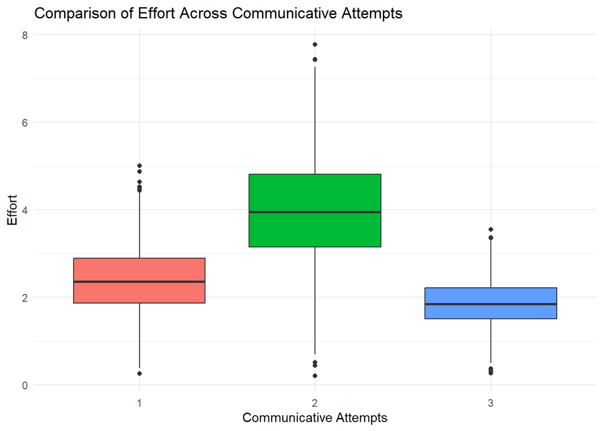

```r
# Load ggplot2
library(ggplot2)
# Sample data (replace this with your actual data)
# df <- data.frame(CommAtt = ..., Eff = ...)

# Create a boxplot comparing Effort across different Communicative Attempts
ggplot(final_data, aes(x = as.factor(CommAtt), y = Eff)) +
  geom_boxplot(aes(fill = as.factor(CommAtt))) +  # Boxplot with fill based on CommAtt
  labs(title = "Comparison of Effort Across Communicative Attempts",
       x = "Communicative Attempts",
       y = "Effort",
       fill = "CommAtt") +
  theme_minimal() +
  theme(legend.position = "none")  # Optional: remove the legend
```

## Question: number of trials = number of concepts?

**Q: Is it by design that each participant had multiples of each concept?**

# Simple linear mixed model

Before we do full Bayesian, we do quick LMM to see whether we are on good track

## Question: contrast coding?

**Q: Do we want to use contrast coding?**

```r
# Convert necessary columns to factors
final_data$CommAtt <- as.factor(final_data$CommAtt)
final_data$Modality <- as.factor(final_data$Modality)
final_data$Participant <- as.factor(final_data$Participant)
final_data$Concept <- as.factor(final_data$Concept)
final_data$TrialNumber <- as.numeric(final_data$TrialNumber)  # Ensure TrialNumber is numeric
```

DP: Check contrasts of factors

```r
contrasts(final_data$CommAtt) <- MASS::contr.sdif(3)
contrasts(final_data$Modality) <- contr.sum(3)/2
```

Centre trial number

```r
final_data$TrialNumber_c <- final_data$TrialNumber - median(range(final_data$TrialNumber))
range(final_data$TrialNumber_c)
```

```
## [1] -26.5  26.5
```

```r
range(final_data$TrialNumber)
```

```
## [1]  1 54
```

Standardize (z-score) all *continuous* predictors.

But if the measures of familiarity, expressibility, and big5 (but is expressibility continuous?) are on a rating scale we can just subtract the median again from these to centre them (and we don’t need to standardize).

```r
final_data$Familiarity <- final_data$Familiarity - median(range(final_data$Familiarity))

final_data$Big5 <- final_data$Big5 - median(range(final_data$Big5))
```

Z-score expressibility

```r
final_data <-
  final_data |>
  mutate(Expressibility_z = (Expressibility - mean(Expressibility))/ sd(final_data$Expressibility, na.rm = T))
```

```r
# Fit the linear mixed-effects model
model <- lmer(Eff ~ CommAtt + Familiarity + Big5 + Expressibility + TrialNumber_c + Modality + (1 | Participant) + (1 | Concept), data = final_data)

# Summary of the model
summary(model)

# Check model diagnostics
# Plot residuals vs fitted values
plot(model)

# Extract coefficients
coefficients <- summary(model)$coefficients
print(coefficients)

# If you want to save the model output
saveRDS(model, here("06_Modeling", "models", "linear_mixed_effects_model.rds"))
```

```r
model <- readRDS(here("06_Modeling", "models", "linear_mixed_effects_model.rds"))
summary(model)
```

```
## Linear mixed model fit by REML ['lmerMod']
## Formula: Eff ~ CommAtt + Familiarity + Big5 + Expressibility + TrialNumber_c +
##     Modality + (1 | Participant) + (1 | Concept)
##    Data: final_data
##
## REML criterion at convergence: 9975.5
##
## Scaled residuals:
##     Min      1Q  Median      3Q     Max
## -5.0841 -0.6303  0.0054  0.6030  4.2185
##
## Random effects:
##  Groups      Name        Variance  Std.Dev.
##  Participant (Intercept) 0.0000000 0.00000
##  Concept     (Intercept) 0.0006344 0.02519
##  Residual                0.4166906 0.64552
## Number of obs: 5055, groups:  Participant, 120; Concept, 21
##
## Fixed effects:
##                  Estimate Std. Error t value
## (Intercept)     1.6100002  0.0237720  67.727
## CommAtt2-1      1.5993689  0.0203652  78.534
## CommAtt3-2     -2.1231784  0.0270728 -78.425
## Familiarity     1.2258134  0.0336060  36.476
## Big5            1.1897779  0.0320081  37.171
## Expressibility  1.2265504  0.0328653  37.321
## TrialNumber_c  -0.0011530  0.0007317  -1.576
## Modality1      -0.5458187  0.0284792 -19.166
## Modality2       0.3023831  0.0259235  11.664
##
## Correlation of Fixed Effects:
##             (Intr) CmA2-1 CmA3-2 Fmlrty Big5   Exprss TrlNm_ Mdlty1
## CommAtt2-1   0.042
## CommAtt3-2   0.122 -0.452
## Familiarity  0.027  0.009 -0.001
## Big5        -0.641  0.009  0.000 -0.092
## Expressblty -0.571  0.011 -0.006 -0.023 -0.001
## TrialNmbr_c  0.154 -0.016 -0.019  0.020  0.019  0.007
## Modality1    0.242  0.002  0.005  0.015  0.004 -0.424 -0.012
## Modality2   -0.128 -0.004  0.000  0.016 -0.002  0.201  0.006 -0.514
## optimizer (nloptwrap) convergence code: 0 (OK)
## boundary (singular) fit: see help('isSingular')
```

The Betas seem quite close to how we create the synthetic data, probably there are some other moderations since the causal relations between the variables are quite complex

## Open question: dyad + participant

**How/whether to include participant in addition to dyad in the random effects**

Our thoughts: participant could maybe be nested within dyad, or do we not need participant? Must be something suggested in the literature.

Participant probably must be included because the Big 5 personality trait measure corresponds to each participant within the dyad.

Check: https://github.com/FredericBlum/exploring-individual-variation-in-turkish-heritage-speakers-complex-linguistic-productions

## Check model diagnostics

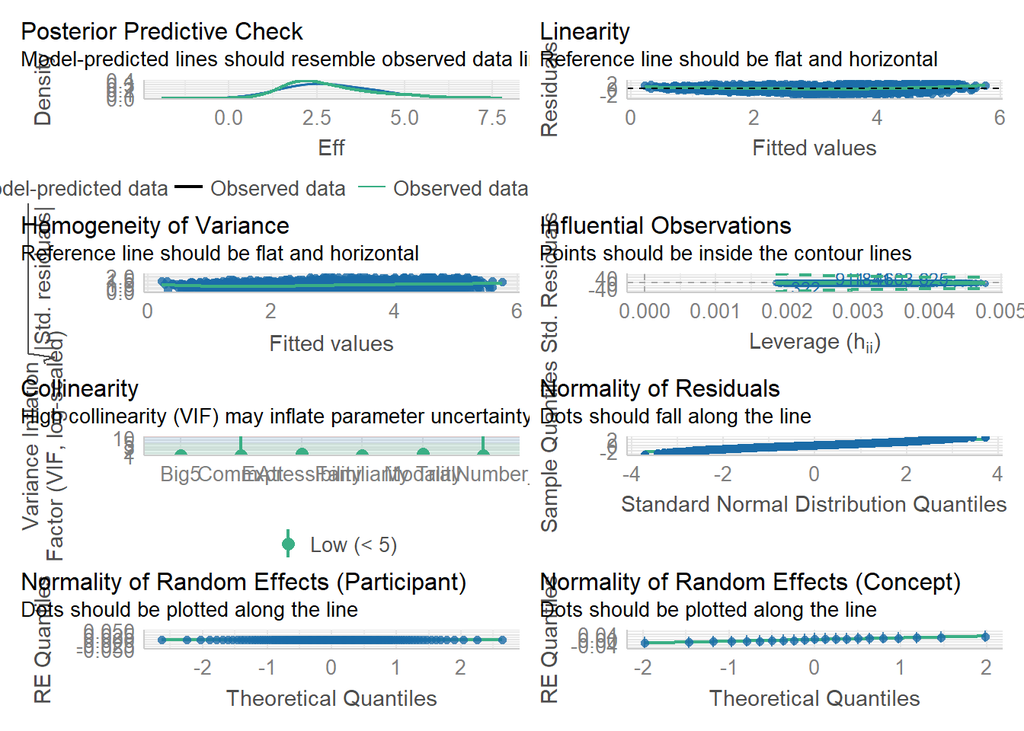

```r
performance::check_model(model)
```

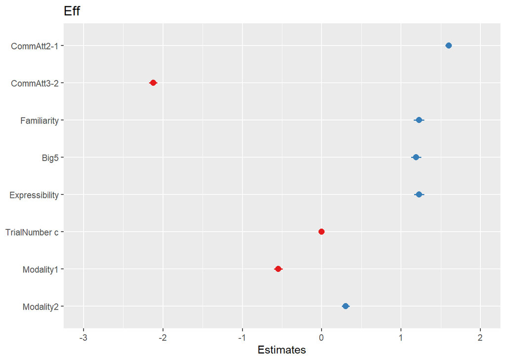

```r
library(sjPlot)

sjPlot::plot_model(model)
```

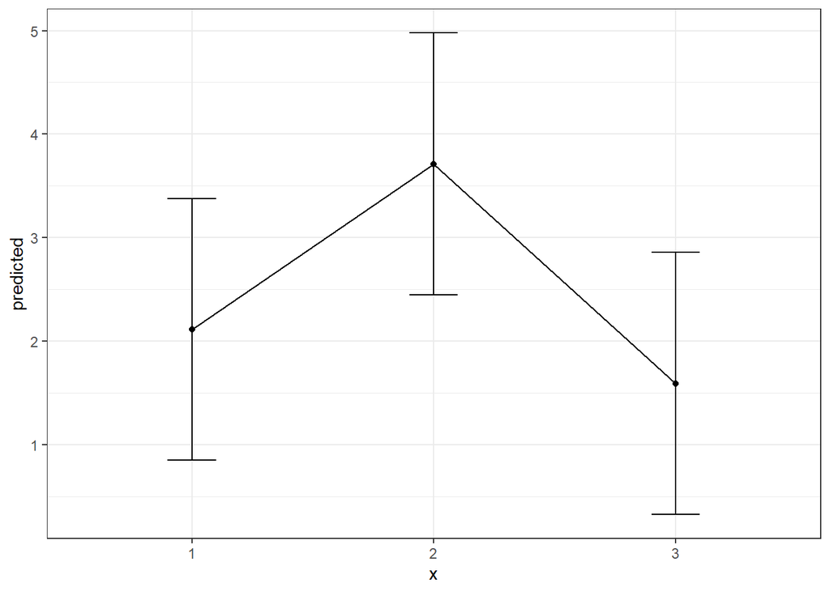

```r
library(ggplot2)
ggeffects::ggpredict(model,
                     terms = c("CommAtt"),
                     type = "random",
                     interval = "confidence") |>
  as_tibble() |>
  ggplot2::ggplot() +
  aes(x = x, y = predicted) +
  geom_point() +
  geom_errorbar(aes(ymin = conf.low, ymax = conf.high), width = .2) +
  geom_line(group = 1) +
  theme_bw()
```

# Bayesian model

Potential ways:

- LMMs - but we assume there might be some non-linearity (e.g., effort will increase in 2nd attempt, but not third)
- b-splines - but our ‘timeline’ consists of only three points (attempts). We could try but maybe b-splines are unncessarilly complex
- ordinal regression
  - see https://solomonkurz.netlify.app/blog/2023-05-21-causal-inference-with-ordinal-regression/ and Chapters 12-13 in McElreath

Eff ~ Normal(μ,σ^2) μ= β0 + β1*CommAtt

```r
library(ggplot2)
library(patchwork)
library(bayesplot)
library(brms)
library(beepr)

# use all available cores for parallel computing
options(mc.cores = parallel::detectCores())
```

Let’s start slowly, first with simple model accounting only for outcome + main predictor

```r
fit_eff1 <- brm(Eff ~ 1 + CommAtt, data=final_data)
saveRDS(fit_eff1, here("06_Modeling", "models", "fit_eff1.rds"))

beep(5)
```

```r
fit_eff1 <- readRDS(here("06_Modeling", "models", "fit_eff1.rds"))

summary(fit_eff1)
```

```
##  Family: gaussian
##   Links: mu = identity; sigma = identity
## Formula: Eff ~ 1 + CommAtt
##    Data: final_data (Number of observations: 5055)
##   Draws: 4 chains, each with iter = 2000; warmup = 1000; thin = 1;
##          total post-warmup draws = 4000
##
## Population-Level Effects:
##            Estimate Est.Error l-95% CI u-95% CI Rhat Bulk_ESS Tail_ESS
## Intercept      2.74      0.01     2.72     2.77 1.00     4017     3144
## CommAtt2M1     1.58      0.03     1.52     1.63 1.00     3578     3162
## CommAtt3M2    -2.12      0.04    -2.19    -2.04 1.00     3399     2958
##
## Family Specific Parameters:
##       Estimate Est.Error l-95% CI u-95% CI Rhat Bulk_ESS Tail_ESS
## sigma     0.89      0.01     0.88     0.91 1.00     4138     3305
##
## Draws were sampled using sampling(NUTS). For each parameter, Bulk_ESS
## and Tail_ESS are effective sample size measures, and Rhat is the potential
## scale reduction factor on split chains (at convergence, Rhat = 1).
```

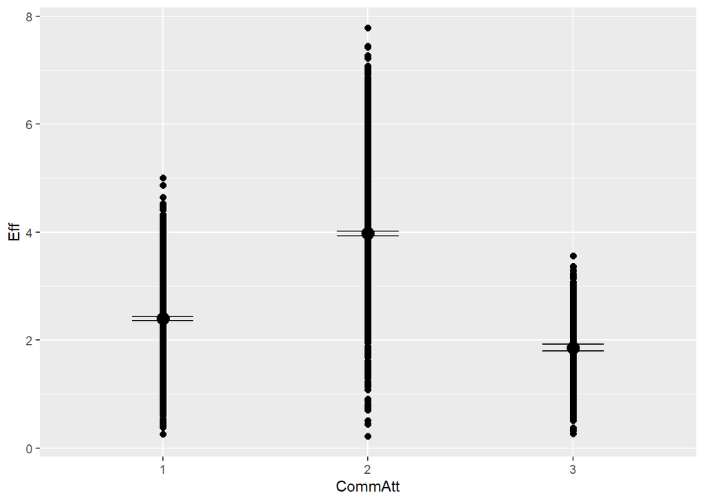

```r
# even so simple model can quite well capture the relationship in the simulated data

plot(conditional_effects(fit_eff1), points = TRUE)
```

```r
# but there is quite a lot of variation, causing overlap

pp_check(fit_eff1, type = "dens_overlay")
```

```
## Using 10 posterior draws for ppc type 'dens_overlay' by default.
```

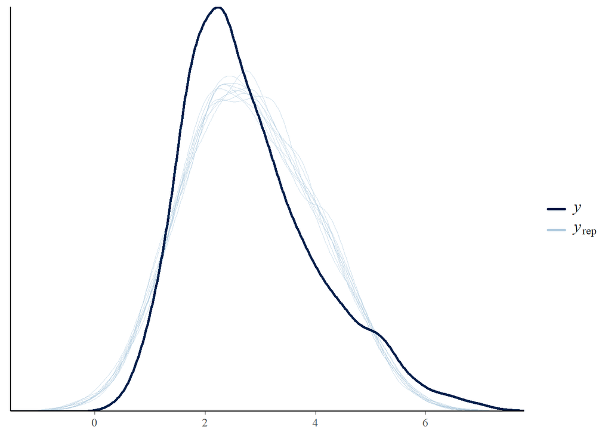

```r
# we see that the simulated data are not that loyal to the data

pp_check(fit_eff1, type = "error_scatter_avg")
```

```
## Using all posterior draws for ppc type 'error_scatter_avg' by default.
```

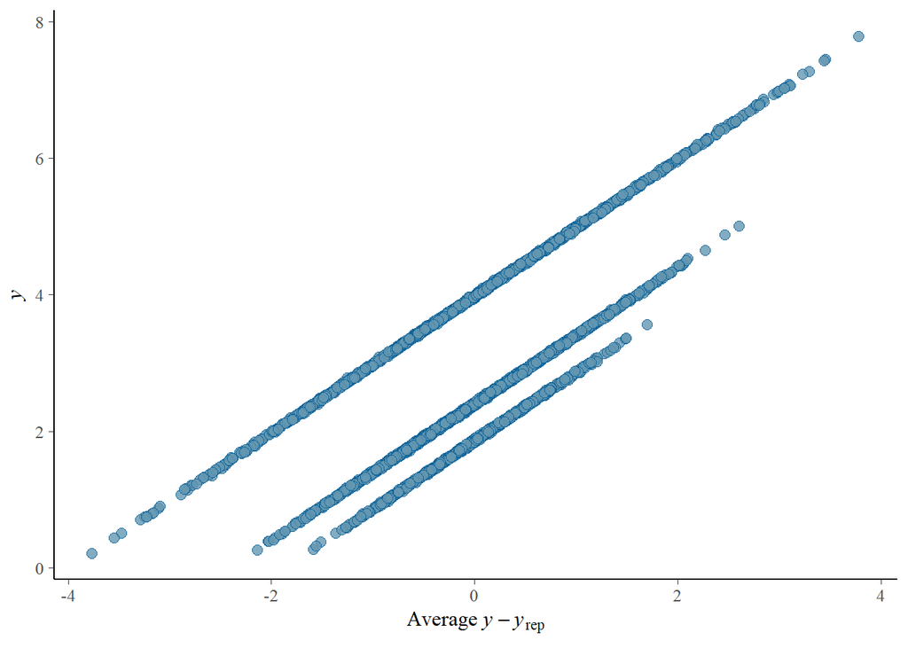

```r
# instead of cloud of points, we see almost perfectly linear relationship between outcome and residuals, indicating strong problems with the independence assumption of the errors.
```

Now we know we will probably need partial pooling for participants, because they share lot of commonalities (Later we might adapt this, because it might be participant within dyads. Dyads might also share lot of commonalities)

```r
fit_eff2 <- brm(Eff ~ 1 + CommAtt + (1 | Participant), data=final_data)
saveRDS(fit_eff2, here("06_Modeling", "models", "fit_eff2.rds"))

beep(5)
```

```r
fit_eff2 <- readRDS(here("06_Modeling", "models", "fit_eff2.rds"))

summary(fit_eff2)
```

```
##  Family: gaussian
##   Links: mu = identity; sigma = identity
## Formula: Eff ~ 1 + CommAtt + (1 | Participant)
##    Data: final_data (Number of observations: 5055)
##   Draws: 4 chains, each with iter = 2000; warmup = 1000; thin = 1;
##          total post-warmup draws = 4000
##
## Group-Level Effects:
## ~Participant (Number of levels: 120)
##               Estimate Est.Error l-95% CI u-95% CI Rhat Bulk_ESS Tail_ESS
## sd(Intercept)     0.51      0.03     0.45     0.58 1.01      406      795
##
## Population-Level Effects:
##            Estimate Est.Error l-95% CI u-95% CI Rhat Bulk_ESS Tail_ESS
## Intercept      2.75      0.05     2.65     2.84 1.02      204      383
## CommAtt2M1     1.59      0.02     1.54     1.63 1.00     4096     3460
## CommAtt3M2    -2.12      0.03    -2.18    -2.06 1.00     3988     3397
##
## Family Specific Parameters:
##       Estimate Est.Error l-95% CI u-95% CI Rhat Bulk_ESS Tail_ESS
## sigma     0.74      0.01     0.72     0.75 1.00     4894     3154
##
## Draws were sampled using sampling(NUTS). For each parameter, Bulk_ESS
## and Tail_ESS are effective sample size measures, and Rhat is the potential
## scale reduction factor on split chains (at convergence, Rhat = 1).
```

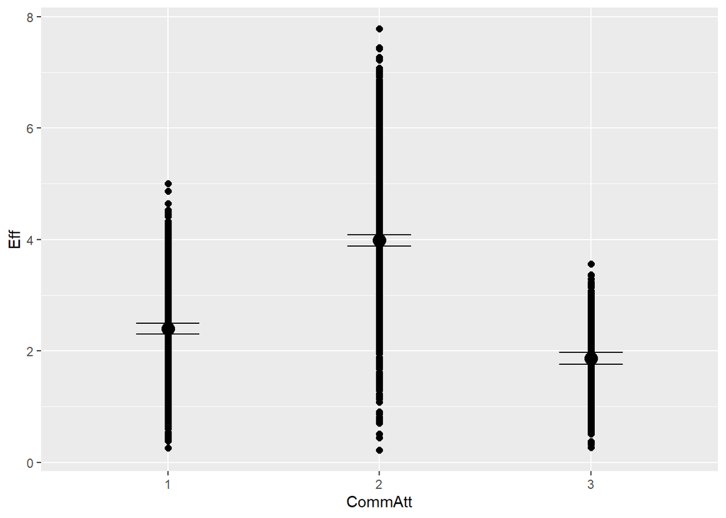

```r
plot(conditional_effects(fit_eff2), points = TRUE)
```

```r
# stays the same

pp_check(fit_eff2, type = "dens_overlay")
```

```
## Using 10 posterior draws for ppc type 'dens_overlay' by default.
```

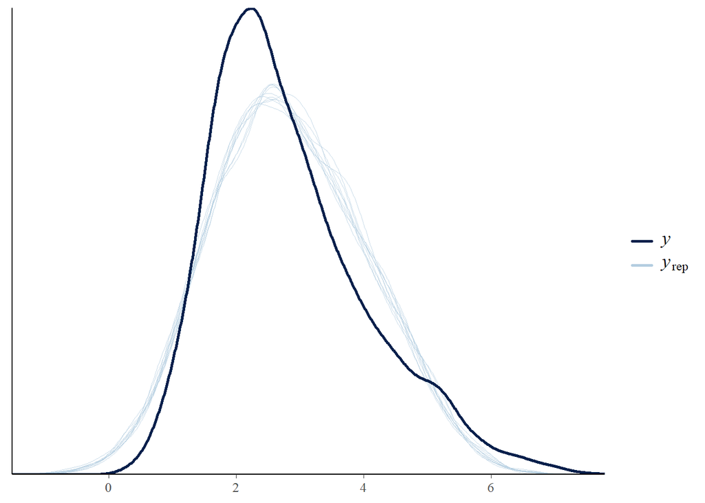

```r
# not really improvement

pp_check(fit_eff2, type = "error_scatter_avg")
```

```
## Using all posterior draws for ppc type 'error_scatter_avg' by default.
```

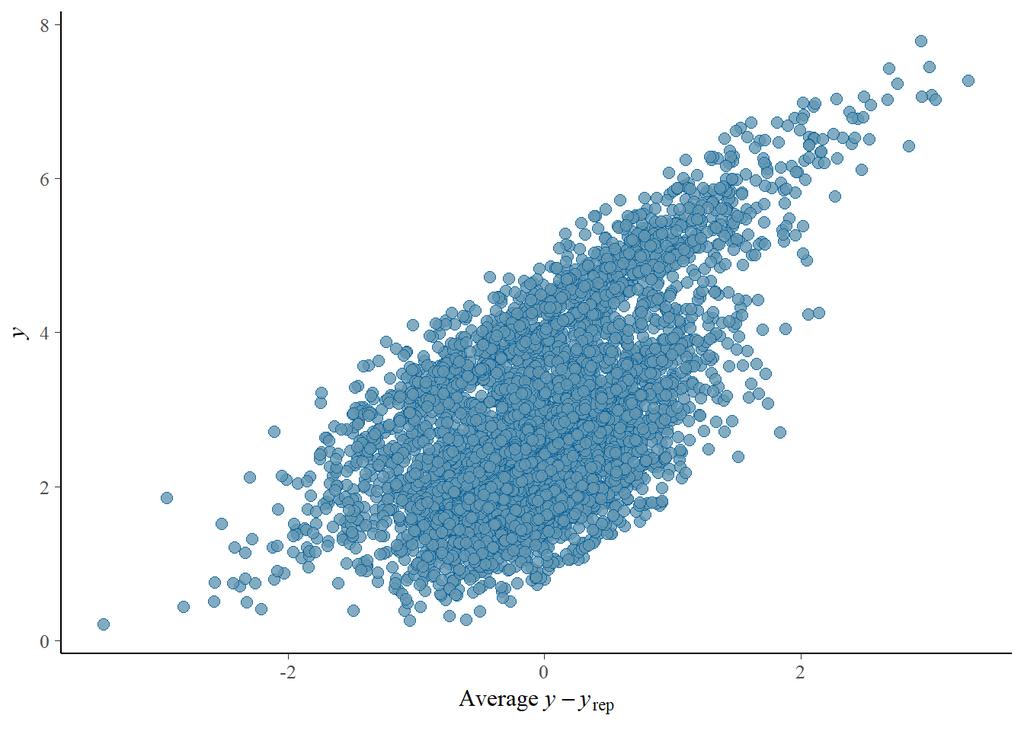

```r
# ok, here we see some improvement here!

# checking to coeff of the parameters
coef(fit_eff2)
```

```
## $Participant
## , , Intercept
##
##     Estimate  Est.Error     Q2.5    Q97.5
## 1   3.579610 0.11441565 3.352994 3.812583
## 2   2.522447 0.11044733 2.314125 2.741480
## 3   3.146291 0.10402491 2.944224 3.347758
## 4   2.262994 0.10891029 2.051830 2.477337
## 5   1.668679 0.11156294 1.453740 1.885679
## 6   3.210786 0.10755374 3.001736 3.421982
## 7   1.743726 0.09956315 1.546578 1.942408
## 8   2.415176 0.11570030 2.188098 2.644443
## 9   2.941818 0.10847545 2.726732 3.153139
## 10  2.850522 0.11247866 2.631404 3.071326
## 11  3.235421 0.10197221 3.035279 3.431147
```

[output cut: 357 more lines]

Some more diagnostics

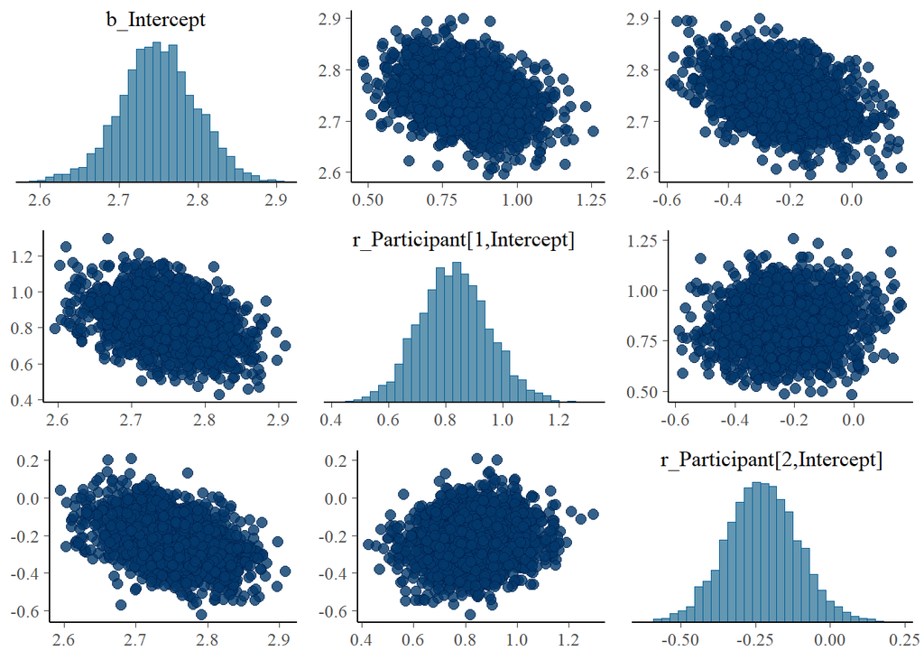

```r
vars <- c("b_Intercept", "r_Participant[1,Intercept]", "r_Participant[2,Intercept]")
pairs(fit_eff2, variable = vars)
```

We see negative correlation between b0 and b0j (and b0j have weak positive correlation with one another)

```r
draws_eff2 <- as.matrix(fit_eff2, variable = vars)
colnames(draws_eff2) <- c("b0", "b0_1", "b0_2")
cors_eff2 <- cor(draws_eff2)
print(cors_eff2, digits = 2)
```

```
##         b0  b0_1  b0_2
## b0    1.00 -0.36 -0.39
## b0_1 -0.36  1.00  0.12
## b0_2 -0.39  0.12  1.00
```

Correlation between the parameters

```r
coef_eff2 <- coef(fit_eff2, summary = FALSE)

print(cor(coef_eff2$Participant[, 1:5, "Intercept"]), digits = 2)
```

```
##        1       2      3     4       5
## 1  1.000 -0.0178 0.0461 0.012 -0.0100
## 2 -0.018  1.0000 0.0039 0.063 -0.0084
## 3  0.046  0.0039 1.0000 0.057  0.0135
## 4  0.012  0.0626 0.0571 1.000  0.0378
## 5 -0.010 -0.0084 0.0135 0.038  1.0000
```

Per-subject predicitons into the plot

[figure not shown]

```r
conditions <- make_conditions(final_data, "Participant")
ce <- conditional_effects(
fit_eff2, conditions = conditions,
re_formula = NULL
)
plot(ce, ncol = 6, points = TRUE)
```

```r
# ok this is too many pcns to see anything:)
```

Compare the first two models

```r
loo_eff1 <- loo(fit_eff1)
loo_eff2 <- loo(fit_eff2)

loo_compare(loo_eff1, loo_eff2)
```

```
##          elpd_diff se_diff
## fit_eff2    0.0       0.0
## fit_eff1 -912.1      38.1
```

Let’s also add varying slope, because ComAtt will too vary across subjects

```r
fit_eff3 <- brm(Eff ~ 1 + CommAtt + (1 + CommAtt | Participant), # note that there was a mistake before
                data=final_data,
                # Number of cores to use
                cores = 4,)
saveRDS(fit_eff3, here("06_Modeling", "models", "fit_eff3.rds"))

beep(5)
```

```r
fit_eff3 <- readRDS(here("06_Modeling", "models", "fit_eff3.rds"))

summary(fit_eff3)
```

[output not shown]

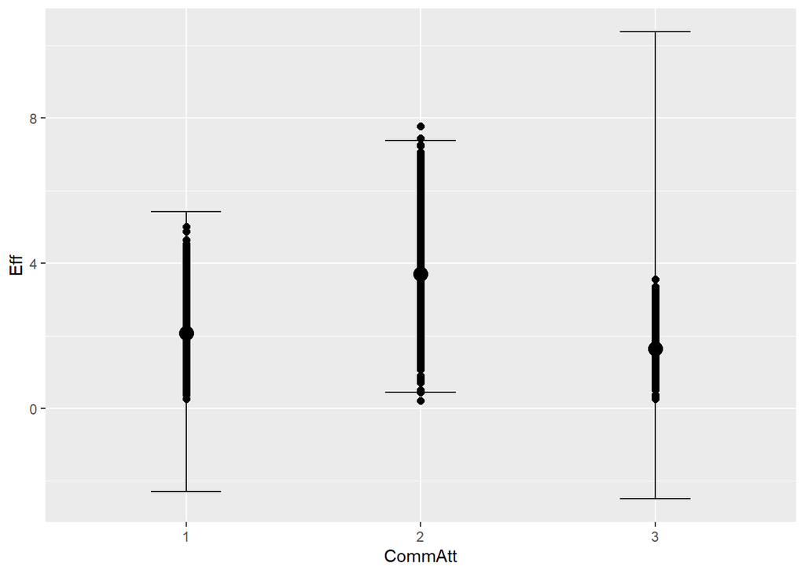

```r
plot(conditional_effects(fit_eff3), points = TRUE)
```

```r
# now the condidence intervals are much wider

pp_check(fit_eff3, type = "dens_overlay")
```

```
## Using 10 posterior draws for ppc type 'dens_overlay' by default.
```

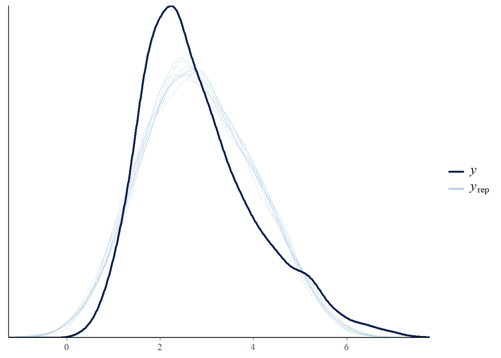

```r
# not really improvement

pp_check(fit_eff3, type = "error_scatter_avg")
```

```
## Using all posterior draws for ppc type 'error_scatter_avg' by default.
```

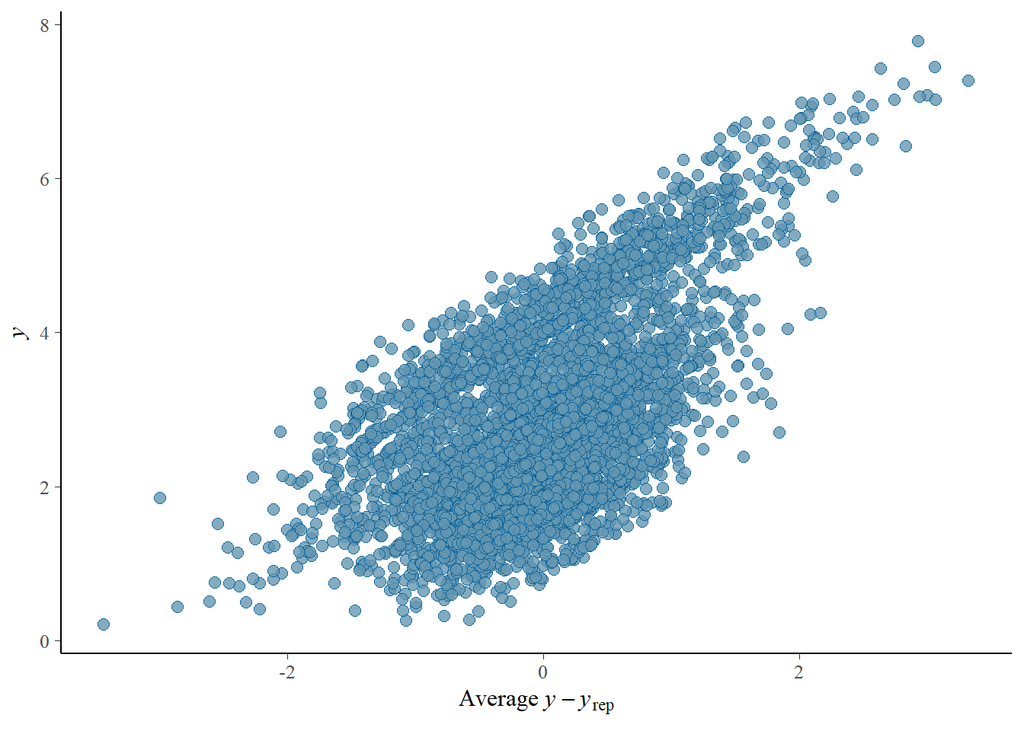

```r
# blobby, but still very correlated
```

Now let’s finally replicate our DAG

```r
fit_eff4 <- brm(Eff ~ 1 + CommAtt + Familiarity + Big5 + Expressibility_z + TrialNumber_c + Modality + (1 | Participant) + (1 | Concept),
                data = final_data,
                cores = 4)

saveRDS(fit_eff4, here("06_Modeling", "models", "fit_eff4.rds"))


beep(5)
```

```r
fit_eff4 <- readRDS(here("06_Modeling", "models", "fit_eff4.rds"))

# summary
summary(fit_eff4)
```

```
##  Family: gaussian
##   Links: mu = identity; sigma = identity
## Formula: Eff ~ 1 + CommAtt + Familiarity + Big5 + Expressibility_z + TrialNumber_c + Modality + (1 | Participant) + (1 | Concept)
##    Data: final_data (Number of observations: 5055)
##   Draws: 4 chains, each with iter = 2000; warmup = 1000; thin = 1;
##          total post-warmup draws = 4000
##
## Group-Level Effects:
## ~Concept (Number of levels: 21)
##               Estimate Est.Error l-95% CI u-95% CI Rhat Bulk_ESS Tail_ESS
## sd(Intercept)     0.03      0.01     0.00     0.06 1.00     1309     1353
##
## ~Participant (Number of levels: 120)
##               Estimate Est.Error l-95% CI u-95% CI Rhat Bulk_ESS Tail_ESS
## sd(Intercept)     0.02      0.01     0.00     0.04 1.00     1886     2247
##
## Population-Level Effects:
##                  Estimate Est.Error l-95% CI u-95% CI Rhat Bulk_ESS Tail_ESS
## Intercept            2.71      0.01     2.69     2.74 1.00     4845     3442
## CommAtt2M1           1.60      0.02     1.56     1.64 1.00     6017     3209
## CommAtt3M2          -2.12      0.03    -2.17    -2.07 1.00     6121     3464
## Familiarity          1.23      0.03     1.16     1.29 1.00     5385     3222
## Big5                 1.19      0.03     1.13     1.25 1.00     5173     3189
## Expressibility_z     0.39      0.01     0.37     0.41 1.00     4850     2713
## TrialNumber_c       -0.00      0.00    -0.00     0.00 1.00     3868     2355
## Modality1           -0.55      0.03    -0.60    -0.49 1.00     5645     2824
## Modality2            0.30      0.03     0.25     0.35 1.00     5678     3188
##
## Family Specific Parameters:
##       Estimate Est.Error l-95% CI u-95% CI Rhat Bulk_ESS Tail_ESS
## sigma     0.65      0.01     0.63     0.66 1.00     6786     2916
##
## Draws were sampled using sampling(NUTS). For each parameter, Bulk_ESS
## and Tail_ESS are effective sample size measures, and Rhat is the potential
## scale reduction factor on split chains (at convergence, Rhat = 1).
```

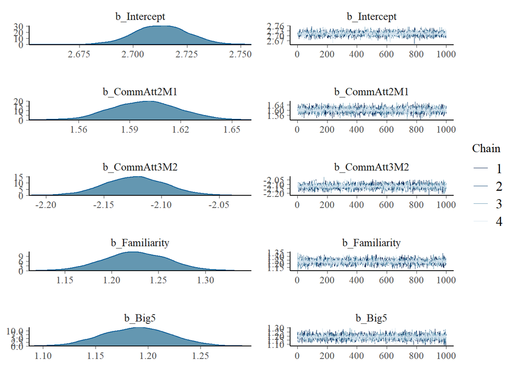

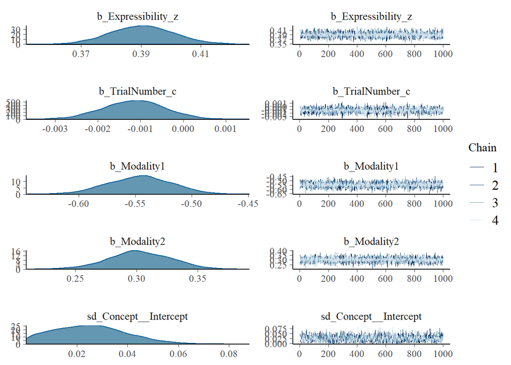

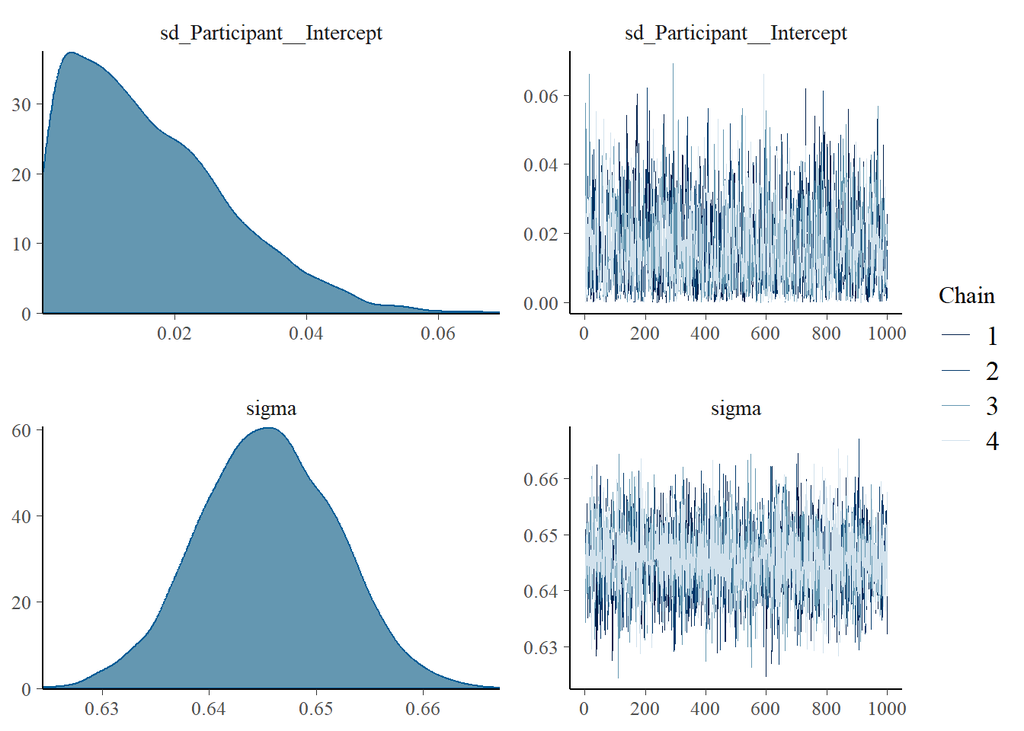

```r
# the coefficients again look similar to what we set in the data (except perhaps expressibility?)

plot(fit_eff4)
```

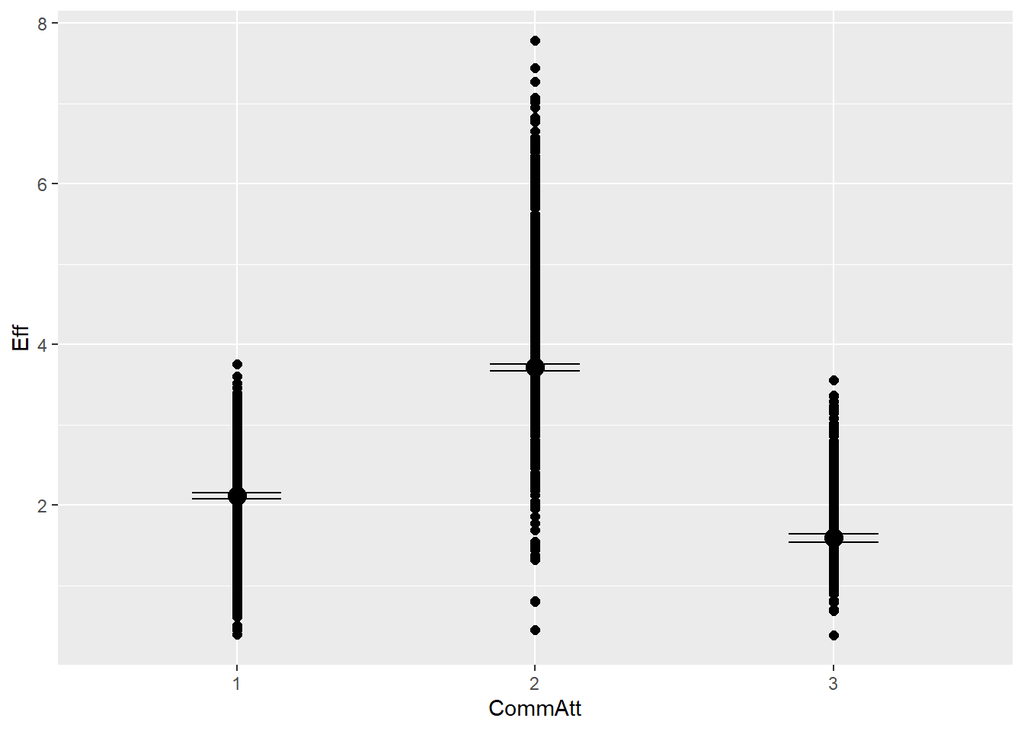

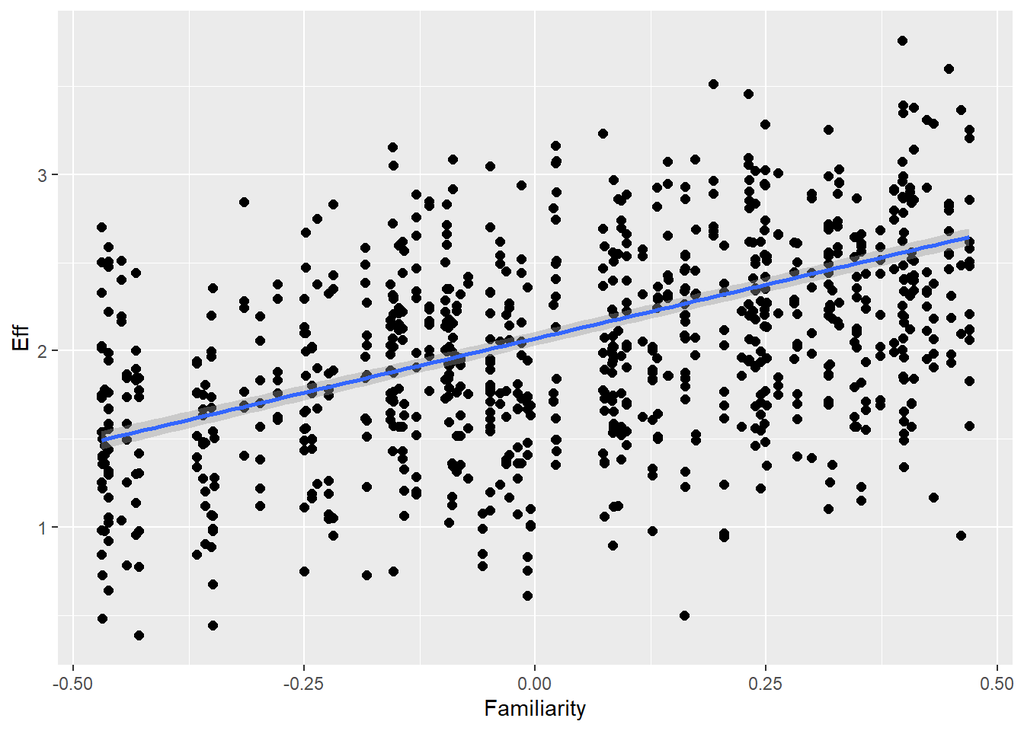

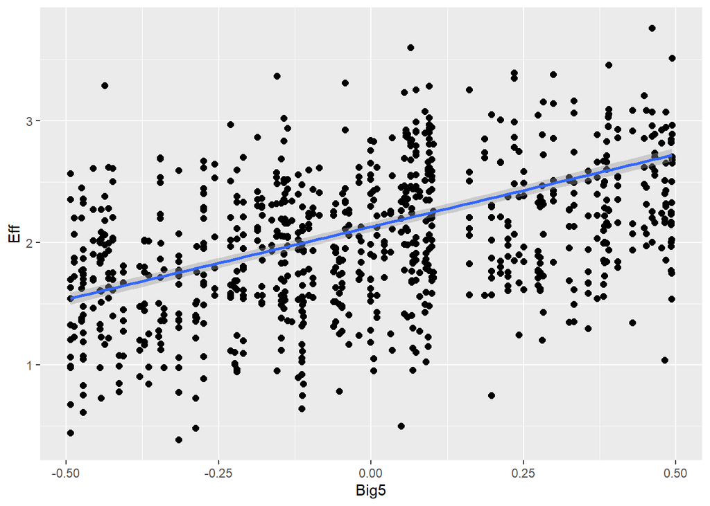

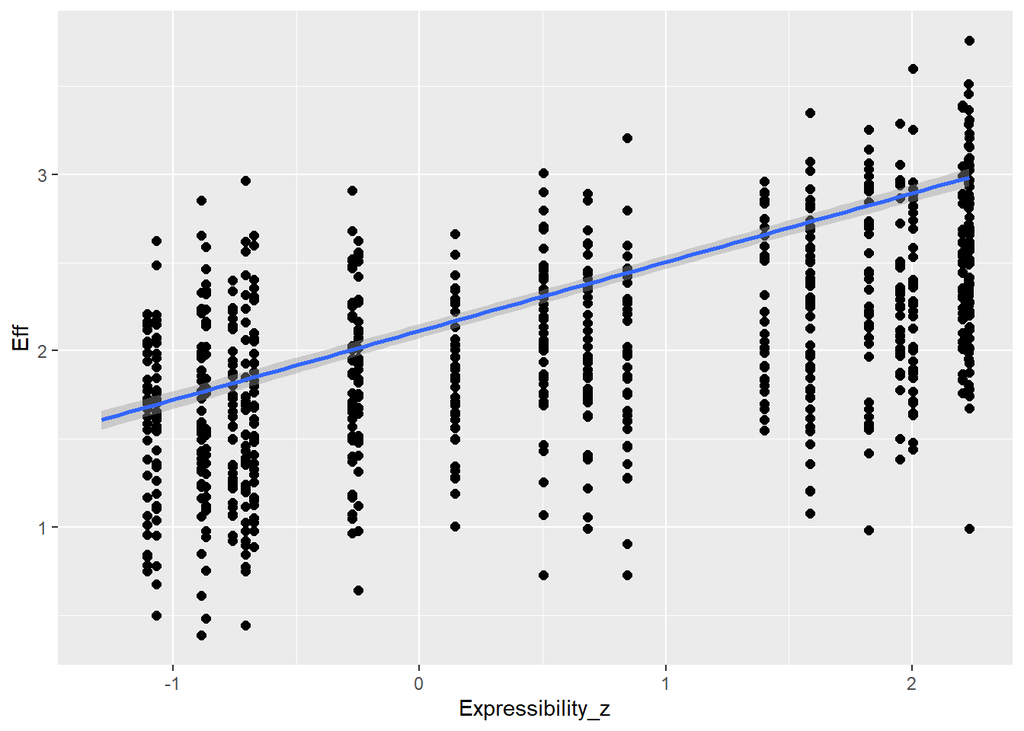

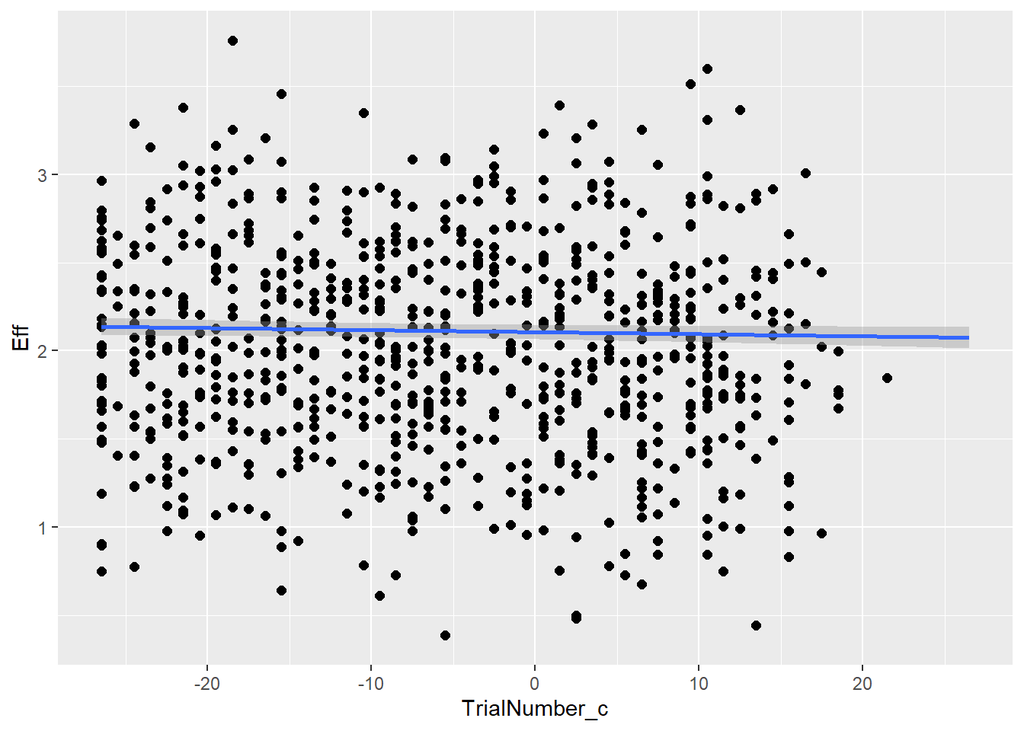

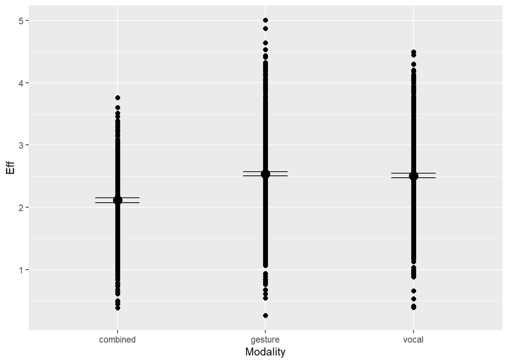

```r
plot(conditional_effects(fit_eff4), points = TRUE)
```

```r
# the CrI are now again in sensible width

pp_check(fit_eff4, type = "dens_overlay")
```

```
## Using 10 posterior draws for ppc type 'dens_overlay' by default.
```

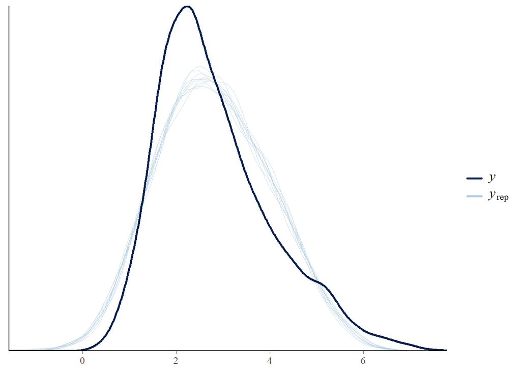

```r
# not really improvement

pp_check(fit_eff4, type = "error_scatter_avg")
```

```
## Using all posterior draws for ppc type 'error_scatter_avg' by default.
```

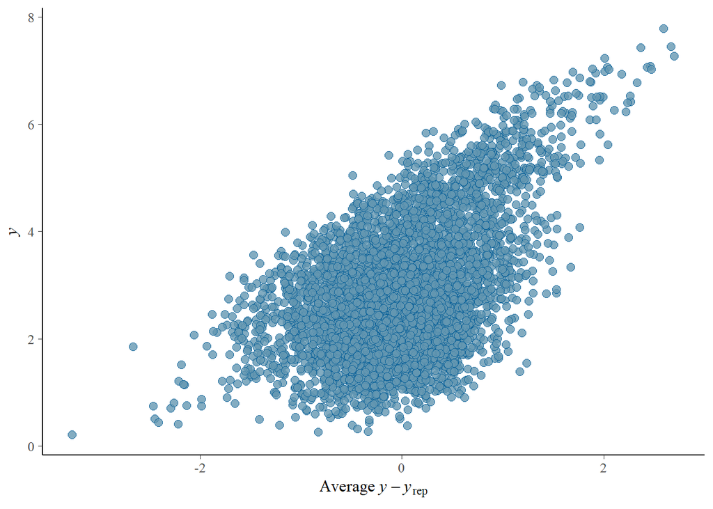

```r
# blobby, but still correlated

# note that we are still missing proper non-def priors
```

## Model with vayring intercepts

```r
fit_eff5 <- brm(Eff ~ 1 + CommAtt + Modality + (1 | Participant) + (1 | Concept) + (1 | Familiarity) + (1 | Big5) + (1 | Expressibility_z) + (1 | TrialNumber_c),
                data = final_data,
                cores = 4)

# NOTE: I accidentally rewrote fit5 with model fit6 so this will need to be re-run and re-saved

saveRDS(fit_eff5, here("06_Modeling", "models", "fit_eff5.rds"))

beep(5)
```

```r
fit_eff5 <- readRDS(here("06_Modeling", "models", "fit_eff5.rds"))

# summary
summary(fit_eff5)
```

[output not shown]

[output cut: 40 more lines]

```
## Population-Level Effects:
##            Estimate Est.Error l-95% CI u-95% CI Rhat Bulk_ESS Tail_ESS
## Intercept      2.76      0.07     2.61     2.90 1.00      361      650
## CommAtt2M1     1.62      0.08     1.46     1.78 1.00      414      698
## CommAtt3M2    -2.15      0.06    -2.26    -2.02 1.01      417      808
## Modality1     -0.87      0.20    -1.24    -0.49 1.02      129      123
## Modality2      0.45      0.11     0.23     0.66 1.02      190      235
##
## Family Specific Parameters:
##       Estimate Est.Error l-95% CI u-95% CI Rhat Bulk_ESS Tail_ESS
## sigma     0.56      0.01     0.54     0.57 1.00     3809     1448
##
## Draws were sampled using sampling(NUTS). For each parameter, Bulk_ESS
## and Tail_ESS are effective sample size measures, and Rhat is the potential
## scale reduction factor on split chains (at convergence, Rhat = 1).
```